# PART-2

# Data Visualization on Honey Production dataset using seaborn and matplotlib libraries.

## QUESTION-1, Import required libraries and read the dataset.

```python
import pandas as pd
import seaborn as sns
import numpy as np
from matplotlib import pyplot as plt
from sklearn.linear_model import LinearRegression
from sklearn import metrics
from scipy.stats import skew
import warnings
warnings.filterwarnings('ignore')
```

## QUESTION-2, Check the first few samples, shape, info of the data and try to familiarize yourself with different features.

```python
df = pd.read_csv(r"C:\Users\md sahbaj alam\Downloads\honeyproduction (1).csv")
```

```python
df
```

|  | state | numcol | yieldpercol | totalprod | stocks | priceperlb | prodvalue | year |
| --- | --- | --- | --- | --- | --- | --- | --- | --- |
| 0 | AL | 16000.0 | 71 | 1136000.0 | 159000.0 | 0.72 | 818000.0 | 1998 |
| 1 | AZ | 55000.0 | 60 | 3300000.0 | 1485000.0 | 0.64 | 2112000.0 | 1998 |
| 2 | AR | 53000.0 | 65 | 3445000.0 | 1688000.0 | 0.59 | 2033000.0 | 1998 |
| 3 | CA | 450000.0 | 83 | 37350000.0 | 12326000.0 | 0.62 | 23157000.0 | 1998 |
| 4 | CO | 27000.0 | 72 | 1944000.0 | 1594000.0 | 0.70 | 1361000.0 | 1998 |
| ... | ... | ... | ... | ... | ... | ... | ... | ... |
| 621 | VA | 4000.0 | 41 | 164000.0 | 23000.0 | 3.77 | 618000.0 | 2012 |
| 622 | WA | 62000.0 | 41 | 2542000.0 | 1017000.0 | 2.38 | 6050000.0 | 2012 |
| 623 | WV | 6000.0 | 48 | 288000.0 | 95000.0 | 2.91 | 838000.0 | 2012 |
| 624 | WI | 60000.0 | 69 | 4140000.0 | 1863000.0 | 2.05 | 8487000.0 | 2012 |
| 625 | WY | 50000.0 | 51 | 2550000.0 | 459000.0 | 1.87 | 4769000.0 | 2012 |

626 rows × 8 columns

```python
df.shape
```

```
(626, 8)
```

```python
df.head(12)
```

|  | state | numcol | yieldpercol | totalprod | stocks | priceperlb | prodvalue | year |
| --- | --- | --- | --- | --- | --- | --- | --- | --- |
| 0 | AL | 16000.0 | 71 | 1136000.0 | 159000.0 | 0.72 | 818000.0 | 1998 |
| 1 | AZ | 55000.0 | 60 | 3300000.0 | 1485000.0 | 0.64 | 2112000.0 | 1998 |
| 2 | AR | 53000.0 | 65 | 3445000.0 | 1688000.0 | 0.59 | 2033000.0 | 1998 |
| 3 | CA | 450000.0 | 83 | 37350000.0 | 12326000.0 | 0.62 | 23157000.0 | 1998 |
| 4 | CO | 27000.0 | 72 | 1944000.0 | 1594000.0 | 0.70 | 1361000.0 | 1998 |
| 5 | FL | 230000.0 | 98 | 22540000.0 | 4508000.0 | 0.64 | 14426000.0 | 1998 |
| 6 | GA | 75000.0 | 56 | 4200000.0 | 307000.0 | 0.69 | 2898000.0 | 1998 |
| 7 | HI | 8000.0 | 118 | 944000.0 | 66000.0 | 0.77 | 727000.0 | 1998 |
| 8 | ID | 120000.0 | 50 | 6000000.0 | 2220000.0 | 0.65 | 3900000.0 | 1998 |
| 9 | IL | 9000.0 | 71 | 639000.0 | 204000.0 | 1.19 | 760000.0 | 1998 |
| 10 | IN | 9000.0 | 92 | 828000.0 | 489000.0 | 0.85 | 704000.0 | 1998 |
| 11 | IA | 50000.0 | 78 | 3900000.0 | 2301000.0 | 0.70 | 2730000.0 | 1998 |

```python
df.tail(8)
```

|  | state | numcol | yieldpercol | totalprod | stocks | priceperlb | prodvalue | year |
| --- | --- | --- | --- | --- | --- | --- | --- | --- |
| 618 | TX | 92000.0 | 52 | 4784000.0 | 718000.0 | 2.00 | 9568000.0 | 2012 |
| 619 | UT | 25000.0 | 38 | 950000.0 | 209000.0 | 1.87 | 1777000.0 | 2012 |
| 620 | VT | 4000.0 | 60 | 240000.0 | 53000.0 | 2.39 | 574000.0 | 2012 |
| 621 | VA | 4000.0 | 41 | 164000.0 | 23000.0 | 3.77 | 618000.0 | 2012 |
| 622 | WA | 62000.0 | 41 | 2542000.0 | 1017000.0 | 2.38 | 6050000.0 | 2012 |
| 623 | WV | 6000.0 | 48 | 288000.0 | 95000.0 | 2.91 | 838000.0 | 2012 |
| 624 | WI | 60000.0 | 69 | 4140000.0 | 1863000.0 | 2.05 | 8487000.0 | 2012 |
| 625 | WY | 50000.0 | 51 | 2550000.0 | 459000.0 | 1.87 | 4769000.0 | 2012 |

```python
df.info()
```

```
<class 'pandas.core.frame.DataFrame'>
RangeIndex: 626 entries, 0 to 625
Data columns (total 8 columns):
 #   Column       Non-Null Count  Dtype
---  ------       --------------  -----
 0   state        626 non-null    object
 1   numcol       626 non-null    float64
 2   yieldpercol  626 non-null    int64
 3   totalprod    626 non-null    float64
 4   stocks       626 non-null    float64
 5   priceperlb   626 non-null    float64
 6   prodvalue    626 non-null    float64
 7   year         626 non-null    int64
dtypes: float64(5), int64(2), object(1)
memory usage: 39.3+ KB
```

```python
df.dtypes
```

```
state           object
numcol         float64
yieldpercol      int64
totalprod      float64
stocks         float64
priceperlb     float64
prodvalue      float64
year             int64
dtype: object
```

```python
df.columns
```

```
Index(['state', 'numcol', 'yieldpercol', 'totalprod', 'stocks', 'priceperlb',
       'prodvalue', 'year'],
      dtype='object')
```

## QUESTION-3, Display the percentage distribution of the data in each year using the pie chart.

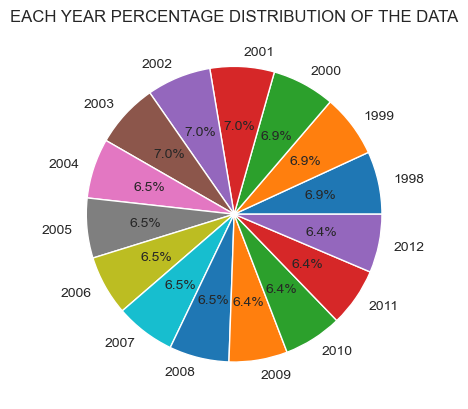

```python
YEAR = df.groupby('year').size()
YEAR.plot(kind='pie', autopct='%1.1f%%')
plt.title('EACH YEAR PERCENTAGE DISTRIBUTION OF THE DATA')
plt.show()
```

## QUESTION-4, Plot and Understand the distribution of the variable "price per lb" using displot, and write your findings.

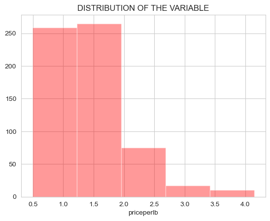

```python
sns.set_style('whitegrid')
plt.title("DISTRIBUTION OF THE VARIABLE")
plt.xlabel("priceperlb")
sns.distplot(df['priceperlb'], kde = False, color ='red', bins = 5)
```

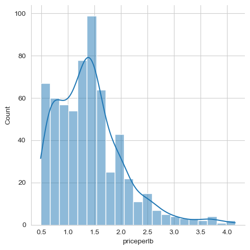

```python
sns.displot(df, x="priceperlb", kde=True)
plt.show()
```

```python
column_skew = skew(df['priceperlb'])
print("Skewness :", column_skew)
```

```
Skewness : 1.1912571643886352
```

*we can see that the distribution of the variable "price per lb" is not normally distributed.*A right-skewed graph indicates that there are more low values in the data set than high values.

## Question-5, . Plot and understand the relationship between the variables 'numcol' and 'prodval' through scatterplot, and write your findings.

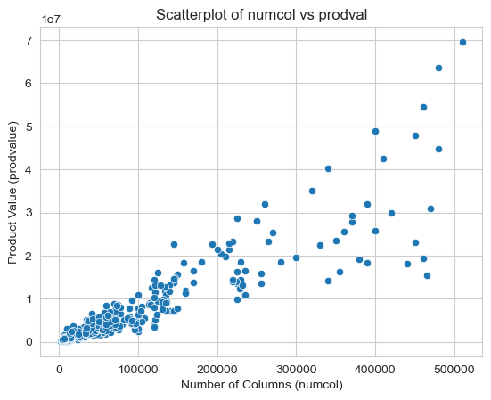

```python
sns.set_style('whitegrid')
sns.scatterplot(x='numcol', y='prodvalue', data=df)

plt.title('Scatterplot of numcol vs prodval')
plt.xlabel('Number of Columns (numcol)')
plt.ylabel('Product Value (prodvalue)')

plt.show()
```

- we can see that there is a positive linear relationship between the variables "numcol" and "prodval".
- there is some variability in the data and the relationship is not perfectly linear.

## QUESTION-6, . Plot and understand the relationship between categorical variable 'year' and a numerical variable 'prodvalue' through boxplot, and write your findings.

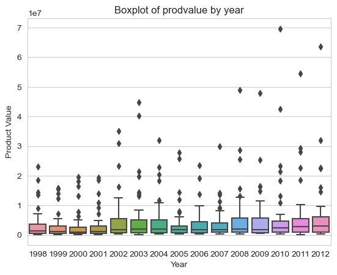

```python
sns.boxplot(x='year', y='prodvalue', data=df)

plt.title('Boxplot of prodvalue by year')
plt.xlabel('Year')
plt.ylabel('Product Value')

plt.show()
```

- In the above box plot each column values have outliers with respect to different year columns and production values.

## QUESTION-7, Visualize and understand the relationship between the multiple pairs of variables throughout different years using pairplot and add your inferences. (use columns 'numcol', 'yield percol', 'total prod', 'prodvalue','year')

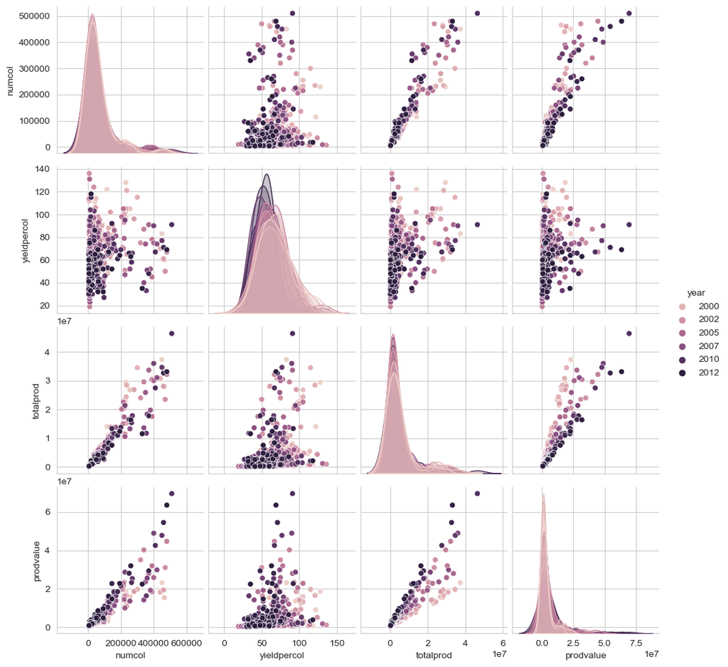

```python
PRPLT = ['numcol', 'yieldpercol', 'totalprod', 'prodvalue', 'year']
sns.pairplot(df[PRPLT], hue="year")
plt.show()
```

## QUESTION-8, Display the correlation values using a plot and add your inferences. (use columns 'numcol', 'yield percol','total prod', 'stocks', 'price per lb', 'prodvalue')

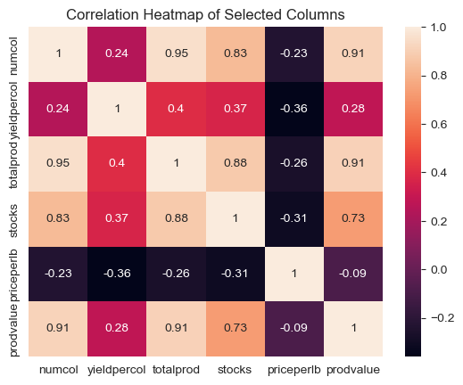

```python
CORR = ['numcol', 'yieldpercol', 'totalprod', 'stocks', 'priceperlb', 'prodvalue']
correlation=df[CORR]
plt.title('Correlation Heatmap of Selected Columns')
corr_matrix = correlation.corr()
sns.heatmap(corr_matrix, annot= True);
```